# Task 6: Exploring NCY Flight Data

Austin Mangelson

2024-06-17

I began this test searching for insightful relationships between two of the variables in the nycflights::flights data set.

I was immediately interested in exploring the relationship between delay times and months of the year.

## Relationship between delays and month of the year

My initial assumption was that there would be greater delay times during the winter months, due to weather conditions.

However, I discovered that the highest average delay times occurred in the summer months of June and July, and actually were the lowest in October and November.

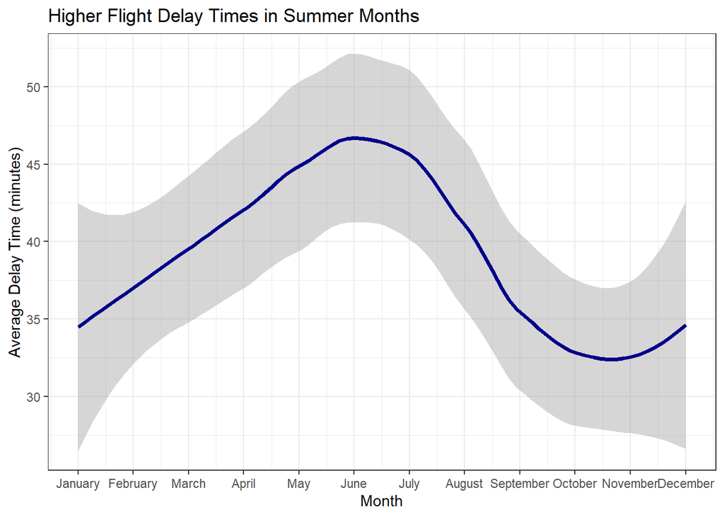

```r
avg_delay <-
  flights |>
  group_by(month) |>
  filter(dep_delay > 0) |>
  summarise(avg_delay_time = mean(dep_delay))
view(avg_delay)

ggplot(avg_delay, aes(x = month, y = avg_delay_time)) +
  geom_smooth(color = "darkblue", linewidth = 1.25, method = "loess", formula = 'y ~ x') +
  theme_bw() +
  labs(
    title = "Higher Flight Delay Times in Summer Months",
    x = "Month",
    y = "Average Delay Time (minutes)"
  ) +
  scale_x_continuous(breaks = seq_along(month.name), labels = month.name)
```

My hypothesis was that this might be due to a higher number of flights in the summer months, leading to a higher average. But again, I was proved wrong when I counted the number of flights each month.

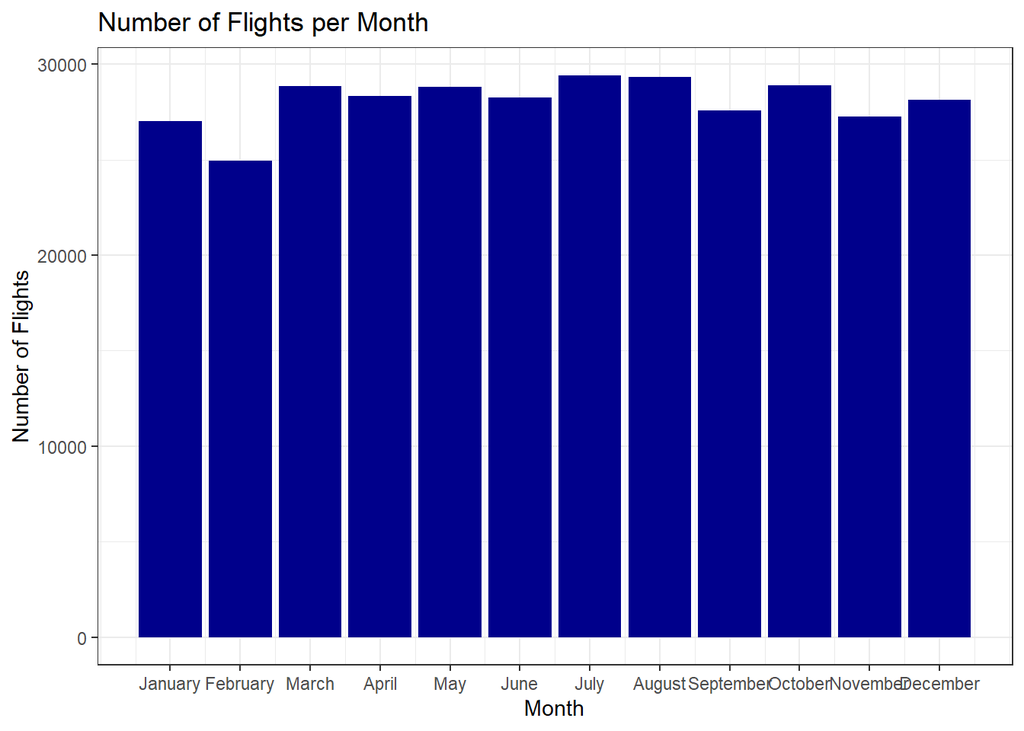

```r
flights_per_month <-
  flights |>
  group_by(month) |>
  summarise(count = n())
view(flights_per_month)

ggplot(flights_per_month, aes(x = month)) +
  geom_col(aes(x = month, y = count), fill = "darkblue") +
  labs(
    title = "Number of Flights per Month",
    x = "Month",
    y = "Number of Flights"
  ) +
  theme_bw() +
  scale_x_continuous(breaks = seq_along(month.name), labels = month.name)
```

This revealed that the differences in number of flights per month is negligible, and that there is relatively no difference between the number of flights between the different seasons of the year.

## Distribution of Delay Times

My final question was about the distribution of delay times. Out of all the flights in 2013, how long were the delays usually? To answer this question, I plotted the departure time against the frequency of delays in hour chunks.

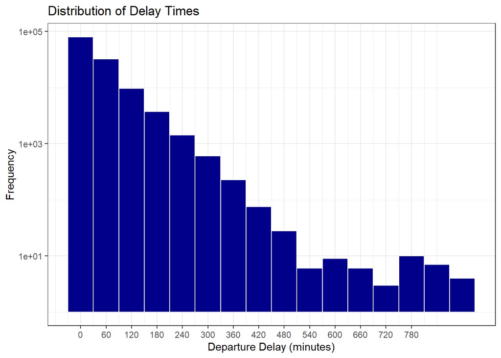

```r
dep_delay_distr <-
  flights |>
  filter(dep_delay > 0, dep_delay < 900)

ggplot(dep_delay_distr, aes(x = dep_delay)) +
  geom_histogram(binwidth = 60, color = "white", fill = "darkblue") +
  scale_y_log10() +
  scale_x_continuous(breaks = seq(0, 780, by = 60)) +
  theme_bw() +
  labs(
    title = "Distribution of Delay Times",
    x = "Departure Delay (minutes)",
    y = "Frequency"
  )
```

From this, I learned that most delays are less than 1 hour long, although I was surprised by the significant number of delays longer than 1 hour.

## Conclusions

The biggest takeaway from this analysis is that the longest average flight delay times happen in the summer, which was contrary to what I had initially guesses. This is not due to the number of flights per month.

My next hypothesis is that these delay times are a result of:

1. Weather, but instead of ice and snow, from thunderstorms and strong winds,
2. Higher passenger volume, leading to longer boarding and deplaning times, or
3. Staff shortages during the summer months

More analysis will have to be done to determine the reasons of these increased delay times.